# Preppin Data 2019 Week 2

David Jackson

10/28/2021

## Next Weeks Weather

So you survived week one (note: if you haven’t completed week one - go back and give it a go as we will be layering the techniques over time)… well done and let’s kick this up a notch.

This week’s challenge uses a few of Jonathan’s and my favourite Tableau Prep features. Prep has a load of great features built in to the menus so let’s see which of them you can use to save you lots of fiddly calculations.

So what’s the data? We need you decide where you are going to in the UK; London or Edinburgh, purely based on the weather (every Brit’s favourite subject).

## Read Weather For London and Edinburgh

```r
rm(list=ls())
weather <- readxl::read_excel("./Data/Week 2019Week-02.xlsx")
weather <- janitor::clean_names(weather) %>%
  select(city,date,metric:value)
```

## Convert to Piviot Wider with meterics being Columns

```r
weather_wider <-weather %>% pivot_wider(names_from =metric,values_from = value) %>% janitor::clean_names()

head(weather_wider)
```

```
## # A tibble: 6 x 7
##   city   date                measure max_temperature min_temperature
##   <chr>  <dttm>              <chr>             <dbl>           <dbl>
## 1 London 2019-02-16 00:00:00 Celsius              13               6
## 2 London 2019-02-16 00:00:00 mm                   NA              NA
## 3 London 2019-02-16 00:00:00 mph                  NA              NA
## 4 London 2019-02-17 00:00:00 Celsius              14               9
## 5 London 2019-02-17 00:00:00 mm                   NA              NA
## 6 London 2019-02-17 00:00:00 mph                  NA              NA
## # ... with 2 more variables: precipitation <dbl>, wind_speed <dbl>
```

### Descriptive Statistics

```r
weather$metric <- as.factor(weather$metric)
weather$city <- as.factor(weather$city)
weather$measure <- as.factor(weather$measure)
summary(weather)
```

```
##         city         date                        metric      measure
##  Edinburgh:28   Min.   :2019-02-16   Max Temperature:14   Celsius:28
##  London   :28   1st Qu.:2019-02-17   Min Temperature:14   mm     :14
##                 Median :2019-02-19   Precipitation  :14   mph    :14
##                 Mean   :2019-02-19   Wind Speed     :14
##                 3rd Qu.:2019-02-21
##                 Max.   :2019-02-22
##      value
##  Min.   : 0.000
##  1st Qu.: 7.750
##  Median : 9.000
##  Mean   : 9.589
##  3rd Qu.:13.000
##  Max.   :20.000
```

### Plot of Daily Min/Max Temps by Date

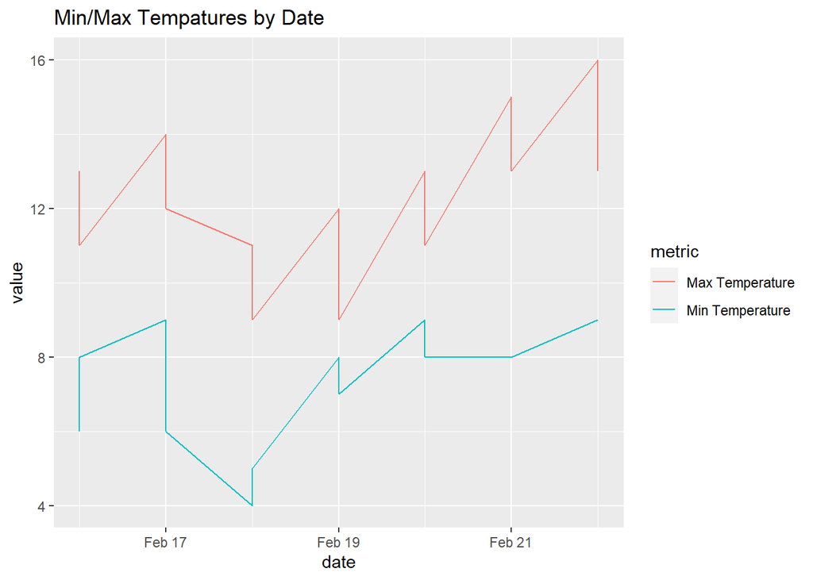

```r
weather %>% filter(measure =="Celsius") %>%
  ggplot(aes(x=date,y=value,group =metric,col=metric)) +
  geom_line() + labs(title = "Min/Max Tempatures by Date")
```

### Plot of Daily Min/Max Temps by City and Dates

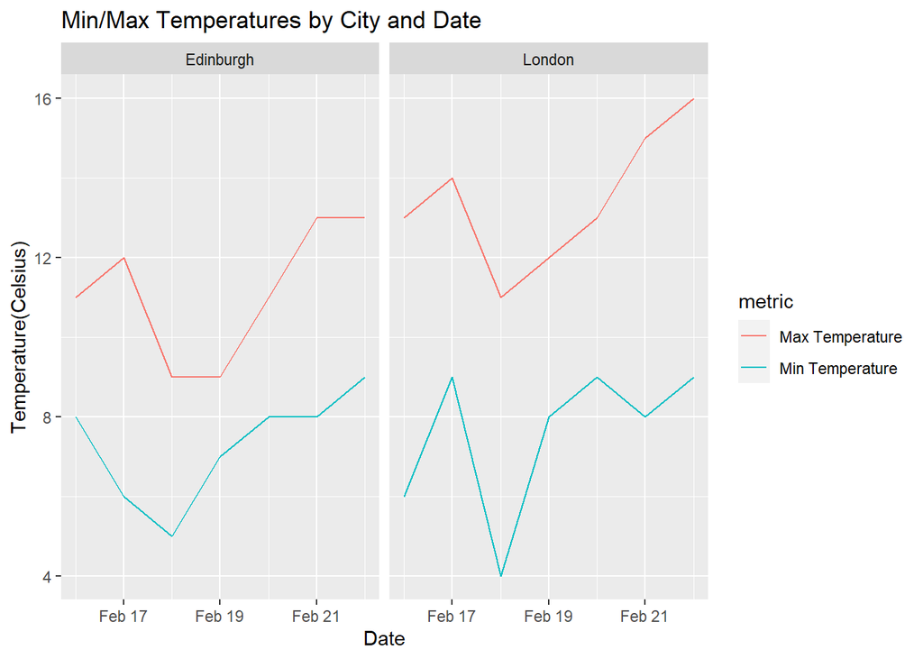

```r
weather %>% filter(measure =="Celsius") %>%
  ggplot(aes(x=date,y=value,group =metric,col=metric)) +
  geom_line() + labs(title = "Min/Max Temperatures by City and Date",
                     x="Date",y="Temperature(Celsius)") +
  facet_wrap(~city)
```

### Plot of Daily Precipitation by Date

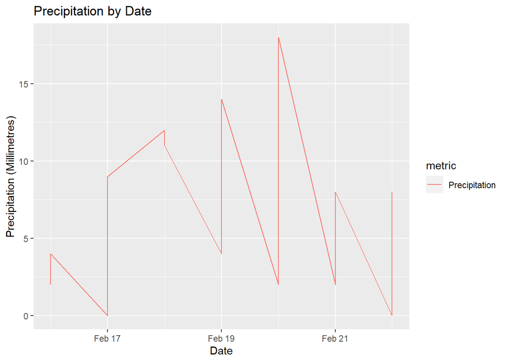

```r
weather %>% filter(measure =="mm") %>%
  ggplot(aes(x=date,y=value,group =metric,col=metric)) +
  geom_line() + labs(title = "Precipitation by Date",x="Date",y="Precipitation (Millimetres)")
```

### Plot of Precipitation City and Dates

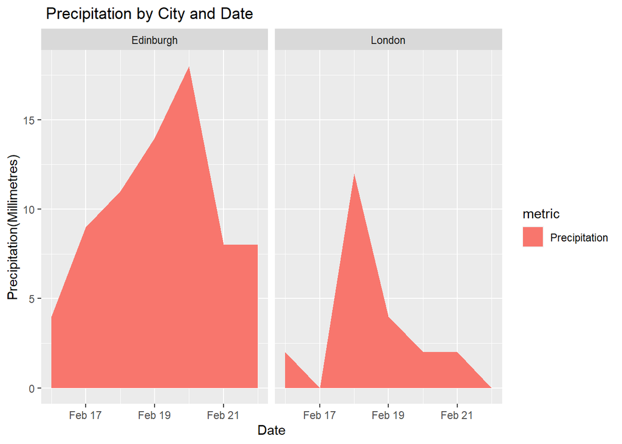

```r
weather %>% filter(measure == "mm") %>%
  ggplot(aes(x=date,y=value,group =metric,fill=metric)) +
  geom_area() + labs(title = " Precipitation by City and Date",
                    x="Date",y="Precipitation(Millimetres)") +
  facet_wrap(~city)
```